# Using Network Measures of Functional Brain Activity to Predict Personality

# Analysis

We will first fit a random forest model to the data. Random forest models are ideal because they can capture nonlinear relationships, and because elastic net based methods are not designed for correlated variables. We also calculated boosting combined with random forest, hypothesizing that we will gain predictive power.

## Parameter Selection

### Random Forest

First we format the data

```r
data.train.full.neoC <- cbind(neoFFData.train$NEOFAC_C, data.train$full)
neoNames = c('NEOFAC_A', 'NEOFAC_O', 'NEOFAC_C', 'NEOFAC_N', 'NEOFAC_E')
df.full <- lapply(neoNames, function(x){
  NEO <- neoFFData.train[,which(names(neoFFData.train) == x)]
  cbind(NEO, data.train$full)
})
names(df.full) <- neoNames
df.partial <- lapply(neoNames, function(x){
  NEO <- neoFFData.train[,which(names(neoFFData.train) == x)]
  cbind(NEO, data.train$partial)
})
names(df.partial) <- neoNames
```

Here, we fit B, the number of trees. One predictor is shown for brevity, but other predictors looked similar. B equal to 1500 was selected.

```r
# tune B
fit.B = randomForest(NEOFAC_C~., data = df.full$NEOFAC_C, ntree = 10000, mtry = 3990) # set mtry to p/3 for now
plot(fit.B)
B = 1500
```

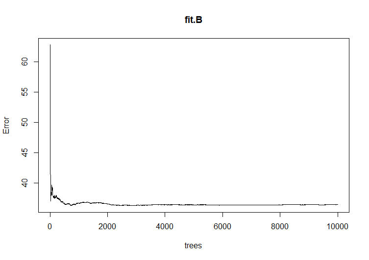

```r
knitr::include_graphics("/Users/jenis/Documents/R/Final/B.png")
```

```r
#Bassett & Sporns 2017
```

Tune mtry

```r
ps = seq(from = 1, to = 6000, by = 500)
rf.error.p <- numeric(length(ps))  # set up a vector
cnt = 0;
for (p in ps)  # repeat the following code inside { } 19 times
{
  print(p)
  cnt = cnt + 1
  fit.rf <-ranger(NEO~., df.partial$NEOFAC_E, mtry = mtry, num.trees = 1500)# set mtry to p/3 for now
  #plot(fit.rf, col= p, lwd = 3)
  rf.error.p[cnt] <- fit.rf$prediction.error  # collecting oob mse based on B trees
}
```

[figure not shown]

```r
knitr::include_graphics("/Users/jenis/Documents/R/Final/mtry.png")
```

### Boosting

Here we attempt to optimize the hyper-parameter choices for our boosing model. This code is currently being run and we anticipate that the properly tuning the parameters of our boosting model will enable us to achieve better predictions on the data. The boosting models presented (code below) have not had paramteter tuning for number of trees or interaction depth, however they provide us some insight on the efficacy of the boosting model for out data.

```r
gbmGrid <- expand.grid(interaction.depth = c(1,2,4,6,8), n.trees = c(5000, 10000, 15000), shrinkage = .1, n.minobsinnode = 10)
fitControl <- trainControl(method = "repeatedcv", number = 10, repeats = 10)


fits.gbm.full <- lapply(df.full, function(x) {
  set.seed(10)
  train(NEO ~ ., data = x,
                 method = "gbm",
                 trControl = fitControl,
                 verbose = TRUE,
                 tuneGrid = gbmGrid,
                 metric = "RMSE",
                 distribution = "gaussian")
})

fits.gbm.partial <- lapply(df.partial, function(x) {
  set.seed(10)
  train(NEO ~ ., data = x,
                 method = "gbm",
                 trControl = fitControl,
                 verbose = TRUE,
                 tuneGrid = gbmGrid,
                 metric = "RMSE",
                 distribution = "gaussian")
})
```